# Right Wing Authoritarianism

# 1 About the task

This data was collected in 2015 from a on-line version of the Right-wing Authoritarianism Scale. At the end of the test but before the results were displayed, respondents were asked if they would be willing to complete an additional survey and allow their responses to be saved for research. Only users who agreed yes are in this dataset. Individuals aged under 13 were not recorded.

# 2 Packages and Data Clean

The following packages were used: tidyverse, here, janitor, ggplot2

The data clean took only those columns that were helpful in answering queries. Several columns were recoded to make the responses more easily interpreted. Some of the questions had their scores inverted as they were assessed using a reversed scale. From the question responses, an RWA score was calculated as the mean from questions 3 to 22. Responses that had extreme responses in family size, test time, age and RWA score were modified or excluded (see Assumptions for more detailed information)

# 3 Assumptions

The columns that are helpful in answer queries were: age, gender, handedness, family size, childhood, education level, test time and the question responses from question 3 to question 22. Questions 1 and 2 are excluded as they are “warm up questions”.

Scores of zero indicate that a question has been left unanswered. If the RWA score, which is an average of the question responses, was zero that would indicate that no questions were answered. These responses were excluded.

It is unreasonable for someone to answer this survey in less than 30 seconds. Any tests completed in under 30 seconds were excluded in their entirety. A maximum time of 2 hours seems more than reasonable. Any time over 7200 was set to NA.

The oldest person in the world in 2015 was 117 years old. Any response with an age over 117 had the age set to NA. There is already a lower limit of 13 on age.

Any respondent who claimed they were one of 21 siblings or more had that entry set as NA. As the question includes the respondent then 0 is not a possible answer. These were also set to NA.

# 4 Analysis

## 4.1 Gender differences

What’s the average RWA score for each gender?

```r
rwa_data %>%
  select(gender, rwa_score) %>%
  group_by(gender) %>%
  summarise(mean_rwa_score = round(mean(rwa_score), 2))
```

| gender | mean_rwa_score |
| --- | --- |
| female | 2.46 |
| male | 3.11 |
| other | 1.87 |
| NA | 2.82 |

Men had the highest mean RWA score at 3.11.  
Women had a mean RWA score of 2.46. Respondents who identified as “other” had a mean RWA score of 1.87. Respondents who didn’t answer the question had a mean RWA score of 2.82.

## 4.2 Handedness

What’s the average RWA score for left handed people vs. right handed people.

```r
rwa_data %>%
  select(hand, rwa_score) %>%
  group_by(hand) %>%
  summarise(mean_rwa_score = round(mean(rwa_score), 2))
```

| hand | mean_rwa_score |
| --- | --- |
| B | 3.17 |
| L | 2.85 |
| R | 2.85 |
| NA | 3.21 |

## 4.3 Family Size vs Childhood

What’s the average family size for each type of childhood?

```r
rwa_data %>%
  select(childhood, familysize) %>%
  group_by(childhood) %>%
  summarise(mean_kids = round(mean(familysize, na.rm = TRUE), 2))
```

| childhood | mean_kids |
| --- | --- |
| rural | 2.84 |
| suburban | 2.63 |
| urban | 2.51 |
| NA | 2.69 |

Family size is defined by the question “Including you, how many children did your mother have?”. Based on this query, there appears to be a trend that the more rural your upbringing, the more maternal siblings you were likely to have had.

## 4.4 Test Time

What’s the average time to take the test for each education level?

```r
rwa_data %>%
  select(education, testelapse) %>%
  group_by(education) %>%
  summarise(mean_time = round(mean(testelapse, na.rm = TRUE), 0)) %>%
  arrange(match(education, c("less than high school", "high school",
                             "university", "postgrad")))
```

| education | mean_time |
| --- | --- |
| less than high school | 329 |
| high school | 308 |
| university | 313 |
| postgrad | 287 |
| NA | 274 |

After removing times that exceeded two hours, there remained no great difference in the average time taken to complete the survey. Respondents who didn’t declare their level of education were fastest, followed by postgraduates, high school graduates and undergraduates. Those who didn’t have a high school education were slowest on average.

## 4.5 Plot of Q4

Create a plot of results of question 4.

Note that the results for question 4 have been reversed. The question was originaly reverse tested, with the results flipped back during cleaning.

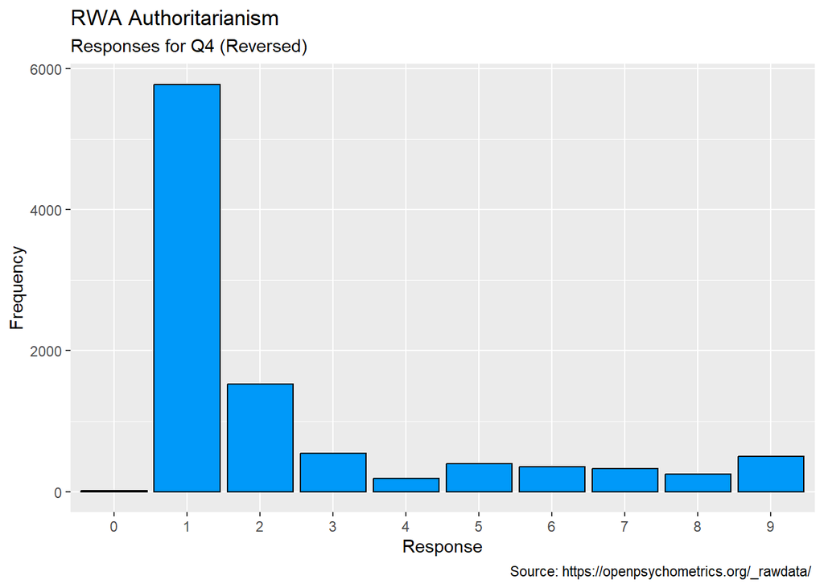

```r
Frequency <- rwa_data %>%
  group_by(q4) %>%
  summarise(Frequency = n()) %>%
  pull(Frequency)

Response <- as.character(c(0:9))

q4data <- data.frame(Response, Frequency)

ggplot(q4data, aes(x = Response, y = Frequency)) +
  geom_col(color = "#000000", fill = "#0099f9") +
  labs(
    title = "RWA Authoritarianism",
    subtitle = "Responses for Q4 (Reversed)",
    caption = "Source: https://openpsychometrics.org/_rawdata/ "
  )
```

## 4.6 Age Bands

What is the average RWA score for people aged under 18, 18 to 25, 26 to 40, 41 to 60, and over 60?

```r
rwa_data %>%
  mutate(age = case_when(age < 18 ~ "Under 18",
                         age <= 25 ~ "18 to 25",
                         age <= 40 ~ "26 to 40",
                         age <= 60 ~ "41 to 60",
                         age <= 116 ~ "Over 60",
                         .default = NA)) %>%
  group_by(age) %>%
  summarise(mean_rwa_score = round(mean(rwa_score), 2)) %>%
  arrange(match(age, c("Under 18", "18 to 25", "26 to 40", "41 to 60",
                       "Over 60", NA)))
```

| age | mean_rwa_score |
| --- | --- |
| Under 18 | 3.36 |
| 18 to 25 | 3.14 |
| 26 to 40 | 2.61 |
| 41 to 60 | 2.53 |
| Over 60 | 2.37 |
| NA | 2.60 |

Based on these age brackets, on average, the younger a respondent was the higher their RWA score was.